# HW4_harinris

Harin Rishabh

2023-11-05

# Lab 5.3

## 5.3.1 The Validation Set Approach

Using the sample() function to split the set of observations into two halves, by selecting a random subset of 196 observations out of the original 392 observations. We refer to these observations as the training set. -train index below selects only the observations that are not in the training set. Using this split of the observations into a training set and a validation set, we find that the validation set error rates for the models with linear, quadratic, and cubic terms are 23.26601, 18.71646, and 18.79401, respectively. This is consistent to previous findings, quadratic function is better than linear and cubic does not improve much.

```r
library(ISLR2)
set.seed(1)
train = sample (392 , 196)
lm.fit <- lm(mpg ~ horsepower , data = Auto , subset = train)
attach(Auto)
mean((mpg - predict(lm.fit , Auto))[-train ]^2)
```

```
## [1] 23.26601
```

```r
lm.fit2 <- lm(mpg ~ poly(horsepower, 2), data = Auto, subset = train)
mean (( mpg - predict(lm.fit2 , Auto))[-train ]^2)
```

```
## [1] 18.71646
```

```r
lm.fit3 <- lm(mpg ~ poly(horsepower, 3), data = Auto, subset = train)
mean((mpg - predict(lm.fit3, Auto))[-train ]^2)
```

```
## [1] 18.79401
```

## 5.3.2 Leave-One-Out Cross-Validation

The LOOCV estimate can be automatically computed for any generalized linear model using the glm() and cv.glm() functions. The cv.glm() function produces a list with several components. The two numbers in the delta vector contain the cross-validation results. We can repeat this procedure for increasingly complex polynomial fits. To automate the process, we use the for() function to initiate a for loop for loop which iteratively fits polynomial regressions for polynomials of order i = 1 to i = 10, computes the associated cross-validation error, and stores it in the i-th element of the vector cv.error. There is a sharp drop in the estimated test MSE between the linear and quadratic fits, but then no clear improvement from using higher-order polynomials.

```r
library(boot)
glm.fit <- glm(mpg ~ horsepower, data = Auto)
cv.err <- cv.glm(Auto, glm.fit)
cv.err$delta
```

```
## [1] 24.23151 24.23114
```

```r
cv.error <- rep(0, 10)
for (i in 1:10) {
  glm.fit <- glm(mpg ~ poly(horsepower , i), data = Auto)
  cv.error[i] <- cv.glm(Auto, glm.fit)$delta[1]
}
cv.error
```

```
##  [1] 24.23151 19.24821 19.33498 19.42443 19.03321 18.97864 18.83305 18.96115
##  [9] 19.06863 19.49093
```

## 5.3.3 k-Fold Cross-Validation

Using cv.glm(), we use k = 10, a common choice for k, on the Auto data set. As expected, we still see no drastic improvement by using higher order polynomials.

```r
set.seed (17)
cv.error.10 <- rep(0, 10)
for (i in 1:10) {
  glm.fit <- glm(mpg ~ poly(horsepower , i), data = Auto)
  cv.error.10[i] <- cv.glm(Auto , glm.fit , K = 10)$delta [1]
}
cv.error.10
```

```
##  [1] 24.27207 19.26909 19.34805 19.29496 19.03198 18.89781 19.12061 19.14666
##  [9] 18.87013 20.95520
```

# 7.8 Lab: Non-linear Modeling

## 7.8.3 GAMs

We are trying to fit a GAM to predict wage using smoothing spline functions of year and age, treating education as a qualitative predictor. We perform 3 different GAMs, a GAM that excludes year (M1), a GAM that uses a linear function of year (M2), or a GAM that uses a spline function of year (M3). We then perform a series of ANOVA tests in order to determine which of these three models is best. We find that there is compelling evidence that a GAM with a linear function of year is better than a GAM that does not include year at all (p-value=0.00014). However, there is no evidence that a non-linear function of year is needed (p-value=0.349)

```r
library(ISLR2)
library(splines)
library(gam)
attach(Wage)
```

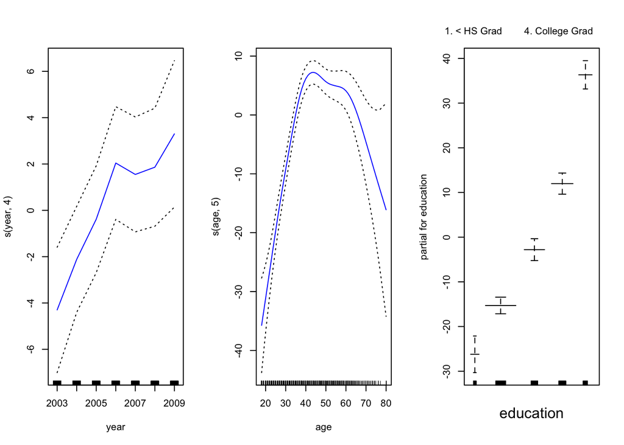

```r
gam.m3 <- gam(wage ~ s(year, 4) + s(age, 5) + education, data = Wage)
par(mfrow = c(1, 3))
plot(gam.m3, se = TRUE , col = "blue")
```

```r
gam.m1 <- gam(wage ~ s(age, 5) + education, data = Wage)
gam.m2 <- gam(wage ~ year + s(age, 5) + education, data = Wage)
anova(gam.m1, gam.m2, gam.m3, test = "F")
```

```
## Analysis of Deviance Table
##
## Model 1: wage ~ s(age, 5) + education
## Model 2: wage ~ year + s(age, 5) + education
## Model 3: wage ~ s(year, 4) + s(age, 5) + education
##   Resid. Df Resid. Dev Df Deviance       F    Pr(>F)
## 1      2990    3711731
## 2      2989    3693842  1  17889.2 14.4771 0.0001447 ***
## 3      2986    3689770  3   4071.1  1.0982 0.3485661
## ---
## Signif. codes:  0 '***' 0.001 '**' 0.01 '*' 0.05 '.' 0.1 ' ' 1
```

```r
summary(gam.m3)
```

```
##
## Call: gam(formula = wage ~ s(year, 4) + s(age, 5) + education, data = Wage)
## Deviance Residuals:
##     Min      1Q  Median      3Q     Max
## -119.43  -19.70   -3.33   14.17  213.48
##
## (Dispersion Parameter for gaussian family taken to be 1235.69)
##
##     Null Deviance: 5222086 on 2999 degrees of freedom
## Residual Deviance: 3689770 on 2986 degrees of freedom
## AIC: 29887.75
##
## Number of Local Scoring Iterations: NA
##
## Anova for Parametric Effects
##              Df  Sum Sq Mean Sq F value    Pr(>F)
## s(year, 4)    1   27162   27162  21.981 2.877e-06 ***
## s(age, 5)     1  195338  195338 158.081 < 2.2e-16 ***
## education     4 1069726  267432 216.423 < 2.2e-16 ***
## Residuals  2986 3689770    1236
## ---
## Signif. codes:  0 '***' 0.001 '**' 0.01 '*' 0.05 '.' 0.1 ' ' 1
##
## Anova for Nonparametric Effects
##             Npar Df Npar F  Pr(F)
## (Intercept)
## s(year, 4)        3  1.086 0.3537
## s(age, 5)         4 32.380 <2e-16 ***
## education
## ---
## Signif. codes:  0 '***' 0.001 '**' 0.01 '*' 0.05 '.' 0.1 ' ' 1
```

We can also use local regression fits as building blocks in a GAM, using the lo() function. Here we have used local regression for the age term, with a span of 0.7.

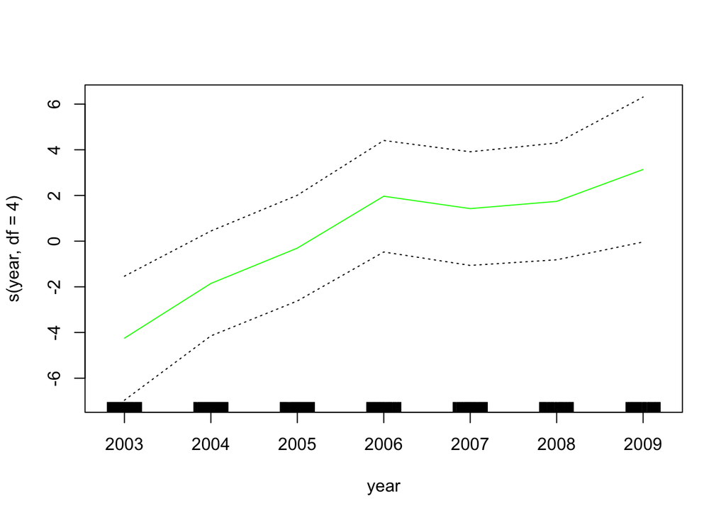

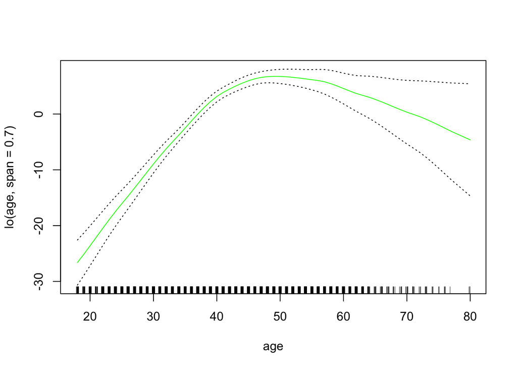

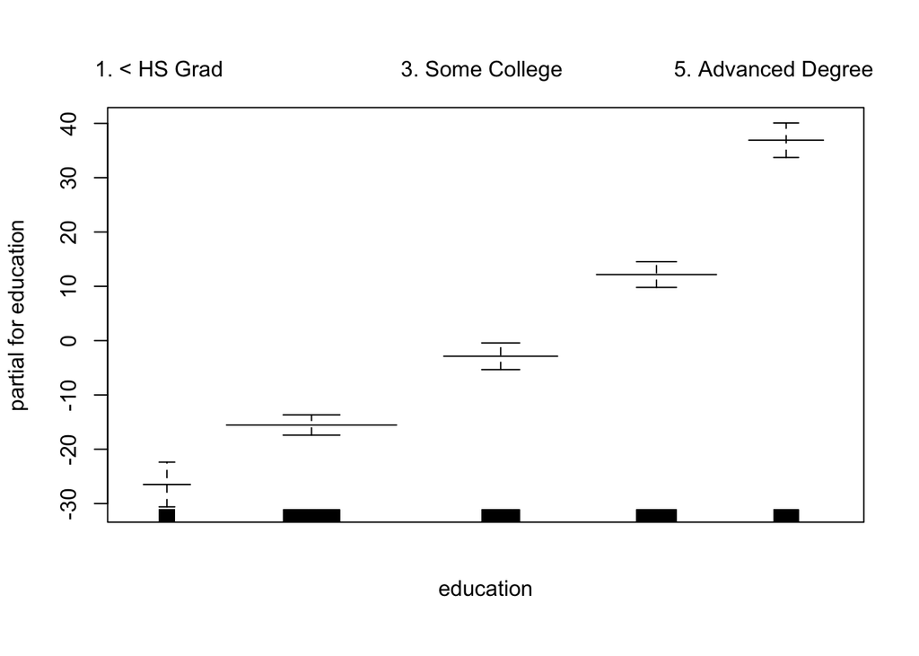

```r
gam.lo <- gam(wage ~ s(year, df = 4) + lo(age, span = 0.7) + education, data = Wage)
plot.Gam(gam.lo, se = TRUE , col = "green")
```

We can also use the lo() function to create interactions before calling the gam() function. Here we fit a two-term model, in which the first term is an interaction between year and age, fit by a local regression surface. We can plot the resulting two-dimensional surface if we first install the akima package.

```r
gam.lo.i <- gam(wage ~ lo(year, age, span = 0.5) + education, data = Wage)
```

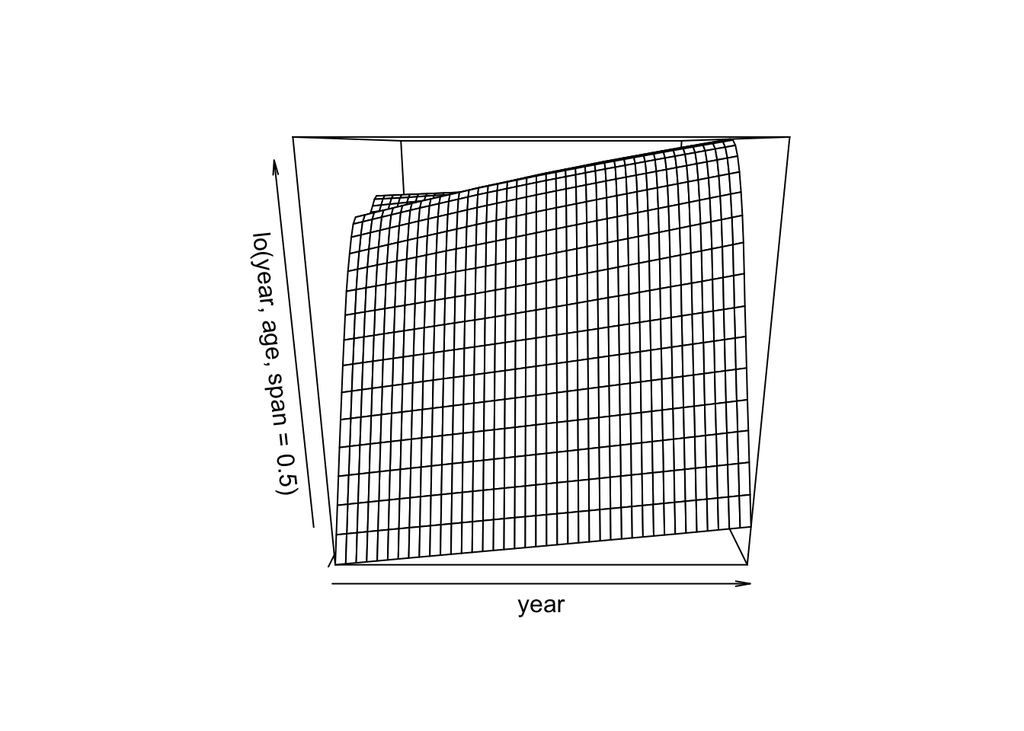

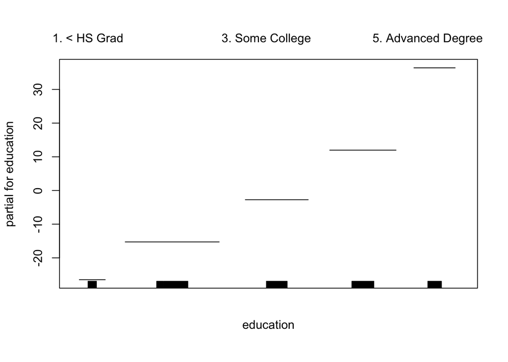

```r
library(akima)
plot(gam.lo.i)
```

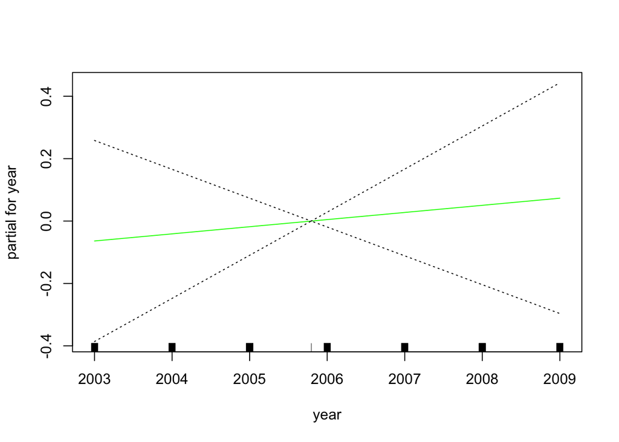

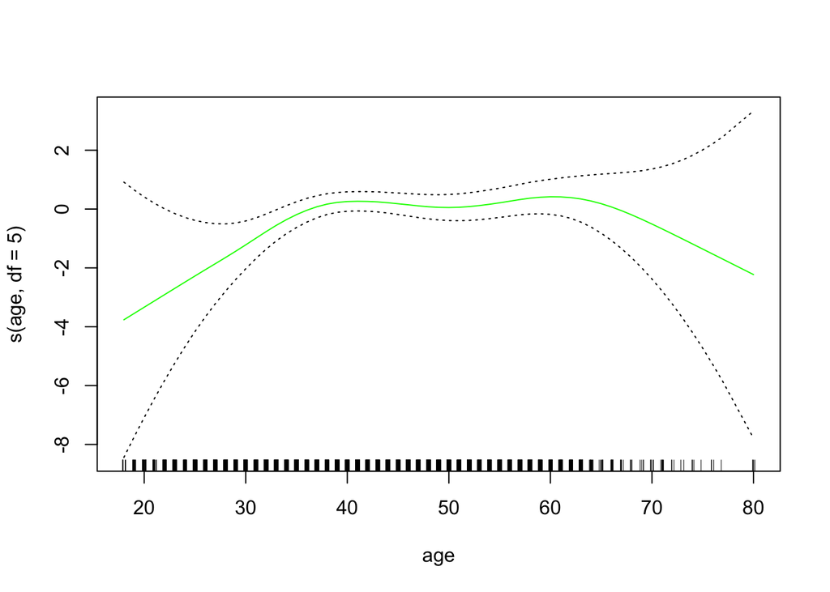

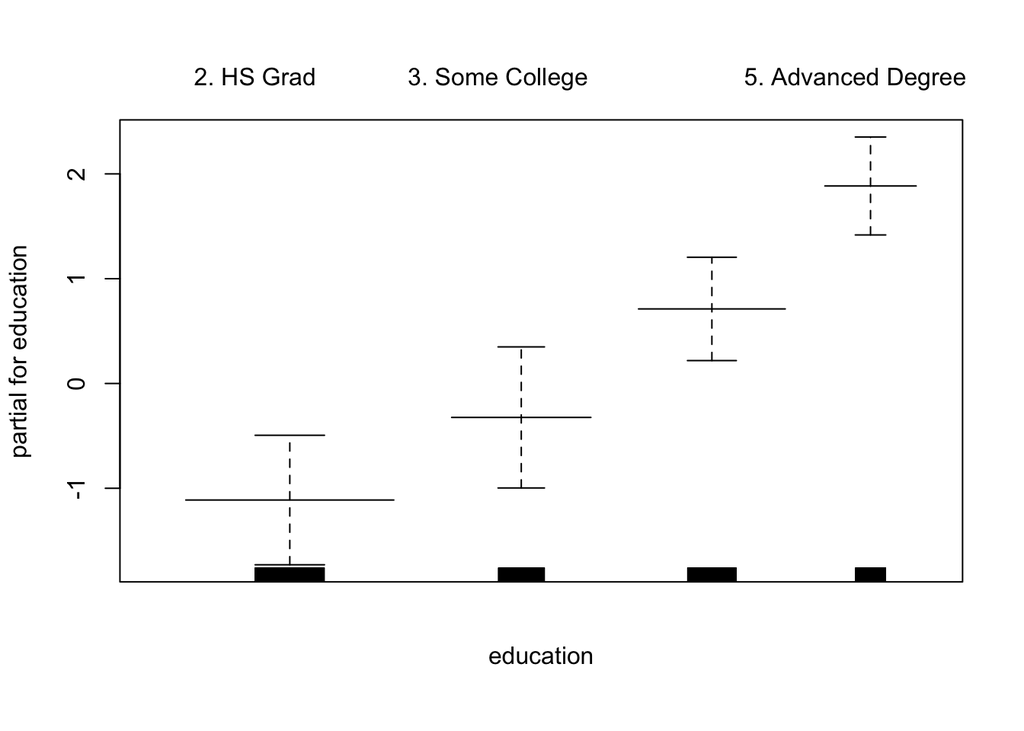

```r
gam.lr.s <- gam(I(wage > 250) ~ year + s(age , df = 5) + education, family = binomial, data = Wage, subset = (education != "1. < HS Grad"))
plot(gam.lr.s, se = T, col = "green")
```

## Exercise 5.4

```r
set.seed (1)
x <- rnorm (100)
y <- x - 2 * x^2 + rnorm (100)
```

**8) b)**  
Answer - From the graph it can be inferred that there is a quadratic relationship between x and y.

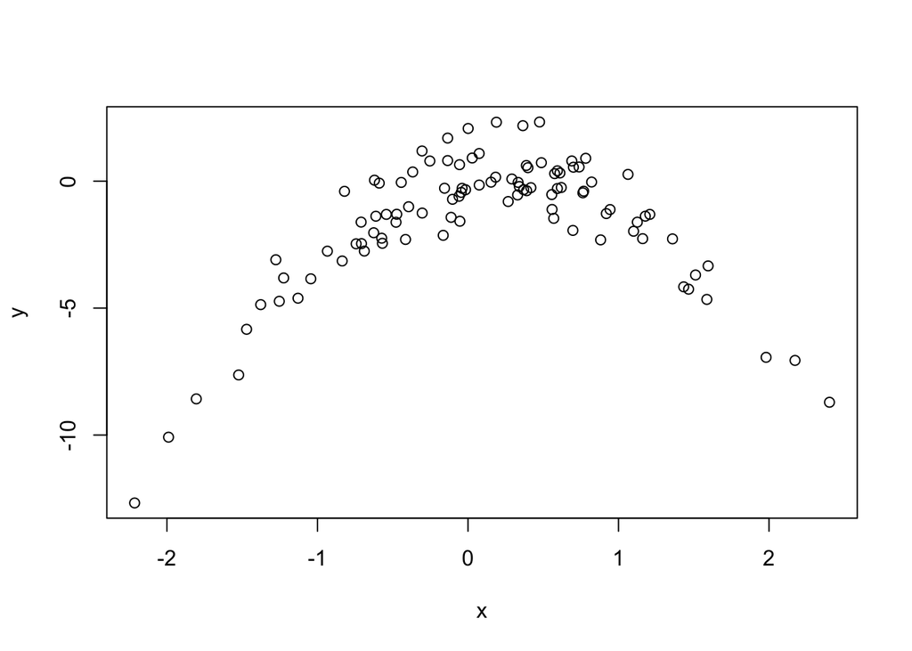

```r
plot(x,y)
```

**8) c) i)**  
Answer -

```r
set.seed(5)
df<-data.frame(x,y)
fit.glm1 <- glm(y ~ x)
cv.glm(df, fit.glm1)$delta[1]
```

```
## [1] 7.288162
```

**8) c) ii)**  
Answer -

```r
fit.glm2 <- glm(y ~ poly(x, 2))
cv.glm(df, fit.glm2)$delta[1]
```

```
## [1] 0.9374236
```

**8) c) iii)**  
Answer -

```r
fit.glm3 <- glm(y ~ poly(x, 3))
cv.glm(df, fit.glm3)$delta[1]
```

```
## [1] 0.9566218
```

**8) c) iv)**  
Answer -

```r
fit.glm4 <- glm(y ~ poly(x, 4))
cv.glm(df, fit.glm4)$delta[1]
```

```
## [1] 0.9539049
```

**8) d)**  
Answer - The results are same as the previous one as the model is built using the entire data set and leaving out one observation.

```r
set.seed(2)
fit.glm5<-glm(y~x)
cv.glm(df,fit.glm5)$delta[1]
```

```
## [1] 7.288162
```

```r
fit.glm6<-glm(y~poly(x,2))
cv.glm(df,fit.glm6)$delta[1]
```

```
## [1] 0.9374236
```

```r
fit.glm7<-glm(y~poly(x,3))
cv.glm(df,fit.glm7)$delta[1]
```

```
## [1] 0.9566218
```

```r
fit.glm8<-glm(y~poly(x,4))
cv.glm(df,fit.glm8)$delta[1]
```

```
## [1] 0.9539049
```

**8) e)**  
Answer - The smallest LOOCV error was seen in the quadratic fit. This was expected as the X-Y plot depicted a quadratic relationship.

**8) f)**  
Answer - There is a significant drop in error from linear to quadratic fit. Higher order polynomials do not show any significant change. This is in line with the conclusions drawn from statistical inference with least error occurring in a quadratic fit.

## Exercise 6.6

**9) a)**  
Answer -

```r
attach(College)
set.seed(1)
train_idx <- sample (1: nrow(College), nrow(College) * 0.7)
train <- College[train_idx, ]
test <- College[-train_idx, ]
```

**9) b)**  
Answer -

```r
lm.fit <- lm(Apps ~ ., data = train)
summary(lm.fit)
```

```
##
## Call:
## lm(formula = Apps ~ ., data = train)
##
## Residuals:
##     Min      1Q  Median      3Q     Max
## -5816.1  -451.6    -1.0   327.2  7445.9
##
## Coefficients:
##               Estimate Std. Error t value Pr(>|t|)
## (Intercept) -5.377e+02  5.076e+02  -1.059  0.28995
## PrivateYes  -5.045e+02  1.648e+02  -3.061  0.00232 **
## Accept       1.722e+00  4.763e-02  36.159  < 2e-16 ***
## Enroll      -1.055e+00  2.437e-01  -4.329 1.80e-05 ***
## Top10perc    5.358e+01  6.440e+00   8.320 7.64e-16 ***
## Top25perc   -1.614e+01  5.092e+00  -3.170  0.00161 **
## F.Undergrad  2.970e-02  4.399e-02   0.675  0.49976
## P.Undergrad  7.162e-02  3.649e-02   1.963  0.05019 .
## Outstate    -8.841e-02  2.176e-02  -4.064 5.57e-05 ***
## Room.Board   1.630e-01  5.577e-02   2.923  0.00362 **
## Books        2.727e-01  2.723e-01   1.001  0.31715
## Personal    -7.316e-03  7.283e-02  -0.100  0.92002
## PhD         -9.676e+00  5.360e+00  -1.805  0.07161 .
## Terminal    -3.781e-01  6.015e+00  -0.063  0.94990
## S.F.Ratio    1.627e+01  1.608e+01   1.012  0.31214
## perc.alumni  2.358e+00  4.853e+00   0.486  0.62722
## Expend       5.986e-02  1.337e-02   4.476 9.34e-06 ***
## Grad.Rate    7.158e+00  3.520e+00   2.034  0.04248 *
## ---
## Signif. codes:  0 '***' 0.001 '**' 0.01 '*' 0.05 '.' 0.1 ' ' 1
##
## Residual standard error: 1022 on 525 degrees of freedom
## Multiple R-squared:  0.9332, Adjusted R-squared:  0.9311
## F-statistic: 431.6 on 17 and 525 DF,  p-value: < 2.2e-16
```

```r
lm.pred <- predict(lm.fit, test)
(mse <- mean((lm.pred - test$Apps)^2))
```

```
## [1] 1261630
```

**9) c)**  
Answer - The test error is slightly lesser than the one obtained for the linear model.

```r
library(glmnet)
train_mat<-model.matrix(Apps~.,data=train)
test_mat<-model.matrix(Apps~.,data=test)
grid <- 10^seq(4, -2, length=100)
ridge.fit <- glmnet(y = train$Apps, x = train_mat, alpha = 0, lambda = grid)
cv.ridge <- cv.glmnet(train_mat, train$Apps, alpha=0, lambda=grid)
bestlambda.ridge = cv.ridge$lambda.min
bestlambda.ridge
```

```
## [1] 0.01
```

```r
pred.newlambdaridge <- predict(ridge.fit, s=bestlambda.ridge, newx = test_mat)
mean((test$Apps-pred.newlambdaridge)^2)
```

```
## [1] 1261530
```

```r
lasso.fit <- glmnet(y = train$Apps, x = train_mat, alpha = 1, lambda = grid)
cv.lasso <- cv.glmnet(train_mat, train$Apps, alpha=1, lambda=grid)
bestlambda.lasso = cv.lasso$lambda.min
bestlambda.lasso
```

```
## [1] 0.01
```

```r
pred.newlambdalasso <- predict(lasso.fit, s=bestlambda.lasso, newx = test_mat)
mean((test$Apps-pred.newlambdalasso)^2)
```

```
## [1] 1261265
```

```r
predict(lasso.fit,s=bestlambda.lasso,type="coefficients")
```

```
## 19 x 1 sparse Matrix of class "dgCMatrix"
##                        s1
## (Intercept) -5.384384e+02
## (Intercept)  .
## PrivateYes  -5.045269e+02
## Accept       1.721659e+00
## Enroll      -1.048412e+00
## Top10perc    5.356105e+01
## Top25perc   -1.612877e+01
## F.Undergrad  2.877066e-02
## P.Undergrad  7.168090e-02
## Outstate    -8.842322e-02
## Room.Board   1.631632e-01
## Books        2.724034e-01
## Personal    -7.259487e-03
## PhD         -9.678860e+00
## Terminal    -3.665986e-01
## S.F.Ratio    1.625575e+01
## perc.alumni  2.340035e+00
## Expend       5.986666e-02
## Grad.Rate    7.155618e+00
```

## Exercise 7.9

**10) a)**  
Answer -

```r
attach(College)
set.seed(1)
train_idx <- sample (1: nrow(College), nrow(College) * 0.7)
train <- College[train_idx, ]
test <- College[-train_idx, ]
```

**10) b)**  
Answer - From the plots, we can say expend seems to have non-linear relationship. Alumni looks to be almost linear. The other plots look mostly linear but show some properties of non-linearity.

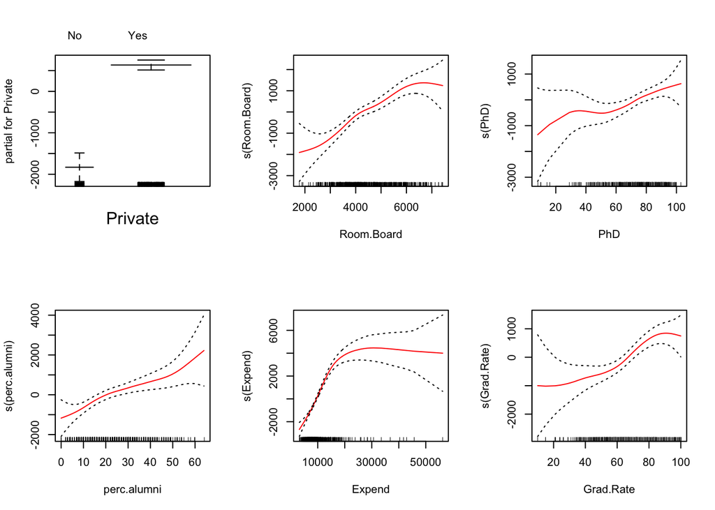

```r
library(leaps)
regfit.fwd <- regsubsets(Outstate ~ ., data = train, method = "forward")
gam.fit <- gam(Outstate ~ Private + s(Room.Board) + s(PhD) + s(perc.alumni) + s(Expend) + s(Grad.Rate), data = train)
par(mfrow = c(2, 3))
plot(gam.fit, se = T, col = "red")
```

```r
mean((predict(gam.fit, newdata = test) - test$Outstate)^2)
```

```
## [1] 3201552
```

**10) d)**  
Answer - In the Anova for Nonparametric Effects table, p-values less that 0.05 indicates non-linear relationships. Expend and Room.Board clearly display non-linear relationships. The rest of the values are not significant enough.

```r
summary(gam.fit)
```

```
##
## Call: gam(formula = Outstate ~ Private + s(Room.Board) + s(PhD) + s(perc.alumni) +
##     s(Expend) + s(Grad.Rate), data = train)
## Deviance Residuals:
##      Min       1Q   Median       3Q      Max
## -7519.76 -1172.56    43.88  1258.04  7823.01
##
## (Dispersion Parameter for gaussian family taken to be 3605337)
##
##     Null Deviance: 9260683704 on 542 degrees of freedom
## Residual Deviance: 1878379197 on 520.9996 degrees of freedom
## AIC: 9762.683
##
## Number of Local Scoring Iterations: NA
##
## Anova for Parametric Effects
##                 Df     Sum Sq    Mean Sq F value    Pr(>F)
## Private          1 2402704131 2402704131 666.430 < 2.2e-16 ***
## s(Room.Board)    1 1721876417 1721876417 477.591 < 2.2e-16 ***
## s(PhD)           1  617453951  617453951 171.261 < 2.2e-16 ***
## s(perc.alumni)   1  458198124  458198124 127.089 < 2.2e-16 ***
## s(Expend)        1  748043911  748043911 207.482 < 2.2e-16 ***
## s(Grad.Rate)     1   99638346   99638346  27.636  2.14e-07 ***
## Residuals      521 1878379197    3605337
## ---
## Signif. codes:  0 '***' 0.001 '**' 0.01 '*' 0.05 '.' 0.1 ' ' 1
##
## Anova for Nonparametric Effects
##                Npar Df Npar F   Pr(F)
## (Intercept)
## Private
## s(Room.Board)        3  2.727 0.04349 *
## s(PhD)               3  1.141 0.33188
## s(perc.alumni)       3  0.987 0.39863
## s(Expend)            3 32.789 < 2e-16 ***
## s(Grad.Rate)         3  2.064 0.10401
## ---
## Signif. codes:  0 '***' 0.001 '**' 0.01 '*' 0.05 '.' 0.1 ' ' 1
```